# Electronic Patient Tracking System Data Quality Assessments (ePTS DQA)

Report on ePTS DQA conducted in Mozambique with patient receiving HIV treatment

Contact: Etelvina Mbalane

PREPARED BY GLOBAL PROGRAMS FOR RESEARCH & TRAINING, UCSF-GP  
Etelvina.Mbalane@ucglobalprograms.org

September, 2018

# 1 Introduction

## 1.1 Background and Rationale

Quality health information is the backbone of quality HIV prevention and care services, supporting the planning, implementation and evaluation of services from the national level to the health facility level (Gimbel et al. (2011)). Reliable, complete and timely health information is essential to providing good patient care and maximizing the benefits of limited health resources at the country level (Consulting (2009)) and (Gimbel et al. (2011)). Program decision-making processes from the health facility level to the National HIV Program rely on data reported via the national health information system to monitor service provision, identify trends in the epidemic, and allocate resources. As such, improving the quality of health information is a priority for the Mozambique Ministry of Health (MoH) and the United States Government (USG) President’s Emergency Plan for AIDS Relief (PEPFAR), a primary funder of HIV prevention and treatment services in Mozambique.

In Mozambique, MOH manages the national electronic health information system (HIS) , called SIS-MA, using a DHIS2 based platform. Currently, most health facilities use standardized paper based tools for data collection and reporting. Monthly reports are sent to MOH district (NED) and province (NEP) statistical centers for retrospective data entry into SIS-MA. To compliment the aggregate national HIS, some PEPFAR supported health facilities (about 400 sites) have individual-level patient tracking systems (EPTS). In these cases, data from paper-based systems are entered into EPTS and monthly reports are generated electronically for MOH and PEPFAR.

Data quality assessments (DQA) help to ensure that reporting systems produce reliable information to guide health service planning and delivery, playing a key role in quality improvement (Weiskopf and Weng (2013)) and (Powell, Davies, and Thomson (2003)). DQA activities can identify underlying issues affecting data quality and strategies, highlighting particular health information system components in need of technical support (Gimbel et al. (2011)). To improve the quality of data in all areas of the system (i.e. original paper-based records, aggregate electronic information in SIS-MA and individual level EMR) PEPFAR Mozambique, MOH and partners have devised a complimentary three-part DQA/DQI strategy: (1) semi-annual internal data quality assessments to measure data quality improvement; (2) annual external data quality to provide audits of the reliability of reported information and (3) semi-annual electronic patient tracking systems (EPTS) DQA to measure the reliability and completeness of information in EPTS as compared to paper based systems.

Internal data quality assessments (iDQA) function to identify gaps and areas for improvement in health facility based data collection and reporting systems, with a participatory quality improvement component that engages a PDSA cycle approach. Assessment results are used as a basis for brainstorming to identify the underlying root causes of poor quality data. Teams led by health facility personnel with support from IPs and provincial MOH authorities devise an Action Plan to correct the issues. Health facility personnel lead implementation with outside monitoring of implementation and support as needed. Six months later, the problem indicators are reassessed.

In contrast, External Data Quality Assessments (eDQA) function is an annual audit to verify the reliability of reported information among a sample of health facilities selected proportional to volume of patients on ART. MOH in collaboration with a non-clinical care partner (JSI/MSIP) lead the eDQA. eDQA offers a generalizable assessment of the quality of clinical data reported up the national data flow. The main differences between the iDQA and eDQA are the sampling approach, team composition, and the objectives of the activities.

EPTS data quality assessments compare the information in PEPFAR partner EPTS to original source records, as a measure of reliability and completeness of data in the EPTS. Results help identify areas for improvement for EPTS data entry. Together, the three methods provide complimentary information and serve synergistic purposes to strengthen the quality of data used for decision-making. These activities started in 2014, and are conducted on a biannual basis (iDQA and EPTS DQA) and annual basis (eDQA).

During all three components (eDQA, iDQA and EPTS DQA) of the data quality strategy, no patient identification information is collected. Center for Disease Control and Prevention (CDC) staff do not engage in data collection, as this process is carried out by the implementing partners, Ministry of Health staff and/or contracted staff (University of California, San Francisco –UCSF and Mozambique Strategic Information Project, M-SIP).

## 1.2 Objectives

1. Evaluate the concordance of data in the primary source paper patient files as compared to data in the electronic patient tracking system (EPTS);
2. Evaluate the completeness of data in the electronic database;
3. Improve the quality of data in ePTS.

# 2 Methods or Procedures

## 2.1 Electronic Patient Tracking System Data Quality Assessments (EPTS DQA)

The data quality assessment on electronic patient tracking system, it’s performed by implementing partners shortly before the last round of SAPR 2018 assessment period, with a sample of patient files to evaluate the completeness and reliability of key variables from patient charts with the information stored into electronic system for patients receiving HIV treatment enrolled in health facilities. The data from the electronic database was compared with sample of data from patient charts.

IP monitoring and evaluation teams conducted EPTS DQA at each health facility they support that has an ePTS. IPS compared selected variables (see Table 2 below) in patient charts with the information stored in the database to measure concordance. For the health facility conducting the first EPTS DQA, reviews a representative sample of patient charts active on ART. For health facilities with subsequent ePTS DQA, engages a convenience sample across select sub-populations (i.e. pediatric patients, TB con-infected patients, ANC patients etc.). Target concordance between patient charts and EPTS is 90% to be considered as good quality of data.

## 2.2 Patient Chart Selection for EPTS DQA

The standard guidelines for care of HIV patients recommends that all health facilities which they are performing first EPTS DQA, they should follow the selection of sample of patient charts using the representative sample procedure and a convenience sample for those health facilities performing the subsequent EPTS DQA.

### 2.2.1 Patient Chart Sampling: Representative Sample

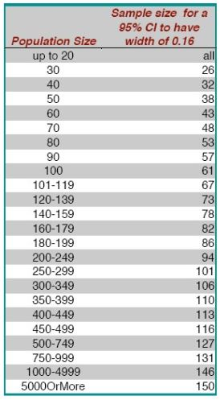

**Table 1**: Representative Sample

1. Determine the sample size using Table 1, based on the total number of patients active on ART during the review period.  
2. Determine the interval size to select a randomized sample of patient charts. Divide the total number of patients active on ART who had at least one consultation during the review period of three months, by the total number of patients in the sample. For example, if there were 43022 patients active on ART with consult and 146 is the sample size, the interval would be 30. 4322/146 = 30  
3. Determine the beginning point for sample selection. Take the interval of 30 and randomly select a number that falls within the interval. For example, if the interval is 1- 30 and the randomly selected number is 8, that will be the first patient chart selected from the total population.  
4. Continue to select starting number plus interval (for example starting point for sample of 30 is the 8th patient on the list, the second is the 38th on the list, the thired is number 68 etc. until the total sample has been selected. If when you go to pull the chart and can’t be located, take the immediate next one. For example, if you cannot locate the chart that is number 38 on the list of all patients active on ART who received a consult during the review period, select the next chart, 39.

### 2.2.2 Convenience Sample for Sub-Sequent EPTS-DQA

After the first EPTS DQA in a facility, the sub-sequent DQA or follow-up DQA uses a convenience sample of 50 charts, from select sub-populations of patients, as follows:

- 10 patients who received ART during a pre-natal consult (ANC)
- 20 adult patients active on ART
- 10 patients from the ART Aderence Community Groups
- 5 pediatric patients on ART
- 5 patients active on ART and also receiving TB treatment

For each sub-population, pull the total sample of patients active on ART. Using the sample size as the interval, select the convenience sample. For example, query the total list of patients who received ART during ANC care during the review period. Pull the chart of the $10^{th}$ patient on the list and continue to pull every $10^{th}$ chart until you have the total sample of 10 charts.

## 2.3 Electronic Patient Tracking System (EPTS) DQA Indicators

EPTS DQA assesses the quality of variables (see table 2) in the database, compared with the information in the clinical files (primary source of the data).

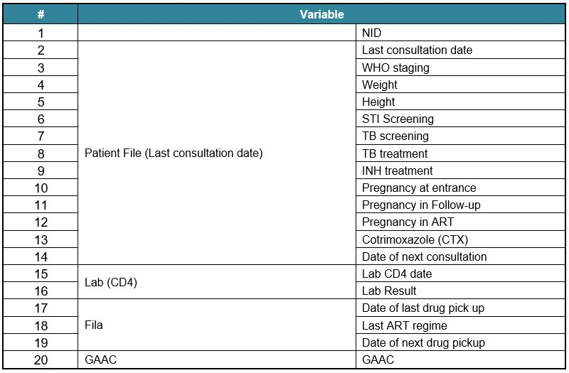

**Table 2**: Variables assessed during the ePTS DQA activities

## 2.4 EPTS DQA Data Collection

Using an Excel book (not shown here), teams pull the charts identified in the patent sampling and compare the data in the charts with the data in the EPTS. Possible results are:

1. **X**: Errors in documentation in patient file: No data in the patient file
2. **0**: Concordance: Data in the patent file and the data in the EPTS match
3. **1**: Missing Data Entry: Data in the patient file has not been entered into the EPTS
4. **2**: Error in Data Entry: Data in the patient file and data in the ePTS do not match
5. Error in documentation: data are in the EPTS but not in the patient file (similar to X)
   1. **3a)** Possible to confirm with another primary source document
   2. **3b)** Data entry error: Not possible to confirm with another primary source document
6. Not Applicable: When the data are not applicable, such as pregnancy for men

Three implementing partners (ARIEL, EGPAF and FGH) used an old Excel tool book for data collection, while CCS and ICAP used the new Excel tool book, which includes new indicators agreed during the workshop held in February, 2018. FHI used both tools: old Excel tool in health facilities from Gondola district and the new Excel tool in the remining health facilities across the country.

## 2.5 EPTS DQA Data Analysis

### 2.5.1 Calculating the Concordance

The concordance divides the absolute value counted in the database by the information found in the clinical file. Concordance is defined by two conditions:

1. Data in the patient chart matches data in the EPTS database (i.e. variable present and is the same value)
2. Data in the patient chart is missing, but it can be confirmed and matched via an alternate primary source, such as pharmacy receipts.

For EPTS DQA the goal is to achieve a 90% concordance with the clinical file data (patient file). If the objective is not reached, actions plans have to be put in place in order to improve the quality of the data.

**Concordance:**

$$\frac{ABS(\mbox{data recounted in EPTS database})}{\mbox{Data recounted in the clinical file or confirmed in an alternate primary document}}$$

It is expected to reach a minimum agreement of 90%. The US with less than 90% agreement is strongly recommended to enhance typing and mentoring for the correct completion of clinical processes.

# 3 Key Findings

## 3.1 Health Facility Sample

IPs conducted EPTS DQA in out of a total of 281[^1] health facilities in Mozambique with EPTS, 278 health facilities. The majority of health facilities were assessed in Maputo province (58), followed by Zambezia (47), Gaza (32), Maputo City (27) and 26 in Inhambane province. The USAID IP for Tete, Manica, Sofala and Niassa assessed less than 20 health facilities per each province, with teams assessing the fewest sites in Niassa (5) and Sofala (7). This is due in part to the low coverage of EPTS in these provinces. Figure 3.1 shows the interactive maps with clustered number of health facilities assessed together with the volume of patients currently on ART[^2] by facility.

[interactive chart not shown]

Figure 3.1: Health facilities assessed across the country

## 3.2 Patient Charts Sample

Table 3.1: Max and Min number of patients files selected with number of sites assessed by province

[output not shown]

Most partners adhered to the representative sampling outlined in Table 1, while some partners assessed a larger sample of patient charts. At two health facilities in Maputo City- HG José Macamo (n=100) and CS Chamanculo- (n=150) the IP selected a sample greater than 50. In Manica province, the IP assessed a large sample at CS Inchope (n=146), while the IP for Gaza province assessed a large sample at CS Zongoene (n=100) and CS Manjangue (n=146). There were some health facilities with a sample of patient files less than 50 and out of scope to be considered as part of the first round of assessment or convenience sample for sub-sequent assessment. More details on sample of patient chart per health facility can be found in Table 3.2.

Table 3.2: List of health facilities with sample of patient files selected by province

| province | district | facility | sample |
| --- | --- | --- | --- |
| Cabo Delgado | Chiure | CS Catapua | 30 |
| Cabo Delgado | Chiure | CS Chiure Velho | 27 |
| Cabo Delgado | Chiure | CS M’mala | 25 |
| Cabo Delgado | Chiure | CS Marera | 30 |
| Cabo Delgado | Chiure | CS Mazeze | 25 |
| Cabo Delgado | Chiure | CS Muege | 24 |
| Cabo Delgado | Chiure | CS Nakoto | 24 |
| Cabo Delgado | Chiure | CS Namogelia | 25 |
| Cabo Delgado | Chiure | CS Samora Machel | 33 |
| Cabo Delgado | Ibo | CS Ibo | 15 |
| Cabo Delgado | Mocimboa da Praia | CS Milamba | 26 |
| Cabo Delgado | Mocimboa da Praia | CS Nanduadua | 29 |
| Cabo Delgado | Mocimboa da Praia | HR Mocimboa da Praia | 50 |
| Cabo Delgado | Muidumbe | CS Chitunda | 35 |
| Cabo Delgado | Muidumbe | CS Miangalewa | 35 |
| Cabo Delgado | Muidumbe | CS Miteda | 35 |
| Cabo Delgado | Muidumbe | CS Muambula | 34 |
| Cabo Delgado | Muidumbe | CS Muatide | 35 |
| Cabo Delgado | Muidumbe | CS Namacande | 35 |
| Cabo Delgado | Muidumbe | CS Ntchinga | 35 |
| Cabo Delgado | Quissanga | CS Bilibiza | 20 |
| Cabo Delgado | Quissanga | CS Cagembe | 20 |
| Cabo Delgado | Quissanga | CS Quissanga | 33 |
| Gaza | Chibuto | CS Chaimite | 50 |
| Gaza | Chibuto | CS Chimundo | 50 |
| Gaza | Chibuto | CS Chipadja | 50 |
| Gaza | Chibuto | CS Coca Missava | 50 |
| Gaza | Chibuto | CS Maqueze | 50 |
| Gaza | Chibuto | CS Meboi | 50 |
| Gaza | Chicualacuala | CS Mapai | 50 |

[output cut: 248 more lines]

## 3.3 Global Concordance Results

We derived the values which corresponds to the global concordance, as the result of the mean of the concordance from the primary souce of variables used to assess this activity whitin each health facility. From table 3.3, it seems that the majority of health facilities had concordance of good quality, i.e, the patient files selected for the assessment matched with the electronic information into the database. There were some health facilities clustered in Gaza and Tete province with global concordance less than the required by the protocol of 90%, meaning that the information from electronic patient system differ from original source. We also see this pattern in some health facilities in Inhambame and Maputo City (in one health facility), Manica (in two health facilities), Nampula and Sofala (in three health facilities) and Zambezia (in five health facilities) with concordance less than 90%, showing mismatch of data into the electronic systems when compared with patient files.

Table 3.3: Global concordance for the sites assessed

| province | district | facility | Concordance |
| --- | --- | --- | --- |
| Cabo Delgado | Chiure | CS Catapua | 100 |
| Cabo Delgado | Chiure | CS Chiure Velho | 98.2 |
| Cabo Delgado | Chiure | CS M’mala | 97.4 |
| Cabo Delgado | Chiure | CS Marera | 98 |
| Cabo Delgado | Chiure | CS Mazeze | 100 |
| Cabo Delgado | Chiure | CS Muege | 100 |
| Cabo Delgado | Chiure | CS Nakoto | 98.2 |
| Cabo Delgado | Chiure | CS Namogelia | 97.1 |
| Cabo Delgado | Chiure | CS Samora Machel | 100 |
| Cabo Delgado | Ibo | CS Ibo | 98.4 |
| Cabo Delgado | Mocimboa da Praia | CS Milamba | 95 |
| Cabo Delgado | Mocimboa da Praia | CS Nanduadua | 100 |
| Cabo Delgado | Mocimboa da Praia | HR Mocimboa da Praia | 95.8 |
| Cabo Delgado | Muidumbe | CS Chitunda | 100 |
| Cabo Delgado | Muidumbe | CS Miangalewa | 100 |
| Cabo Delgado | Muidumbe | CS Miteda | 100 |
| Cabo Delgado | Muidumbe | CS Muambula | 100 |
| Cabo Delgado | Muidumbe | CS Muatide | 100 |
| Cabo Delgado | Muidumbe | CS Namacande | 100 |
| Cabo Delgado | Muidumbe | CS Ntchinga | 100 |
| Cabo Delgado | Quissanga | CS Bilibiza | 96.5 |
| Cabo Delgado | Quissanga | CS Cagembe | 99.7 |
| Cabo Delgado | Quissanga | CS Quissanga | 93.7 |
| Gaza | Chibuto | CS Chaimite | 98.5 |
| Gaza | Chibuto | CS Chimundo | 88.7 |
| Gaza | Chibuto | CS Chipadja | 93.1 |
| Gaza | Chibuto | CS Coca Missava | 87 |
| Gaza | Chibuto | CS Maqueze | 87.2 |
| Gaza | Chibuto | CS Meboi | 87.7 |
| Gaza | Chicualacuala | CS Mapai | 85.9 |

[output cut: 248 more lines]

## 3.4 Quality Issues by Variable

We analyzed each issue in the assessment of EPTS related to the documentation error, data entry error and lack of data entry, looking specifically to the variables from the primary sources of data, used for concordance assessment by province.

### 3.4.1 Quality issues related to **documentation error** by variable in each province

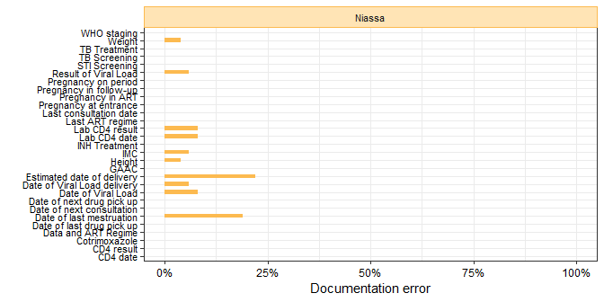

Figure 3.2: Percentage related to documentation error in Niassa

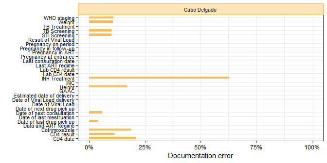

Figure 3.3: Percentage related to documentation error in Cabo Delgado

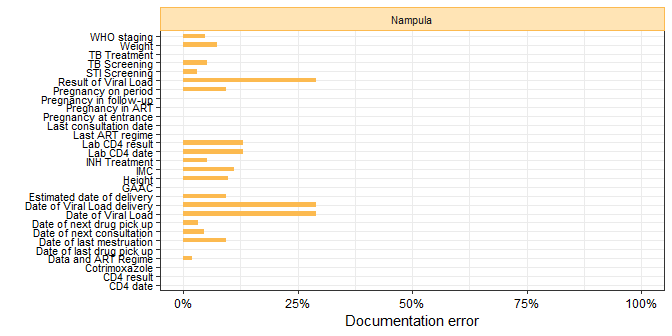

Figure 3.4: Percentage related to documentation error in Nampula

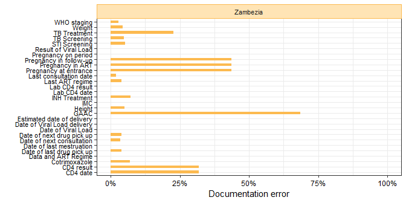

Figure 3.5: Percentage related to documentation error in Zambezia

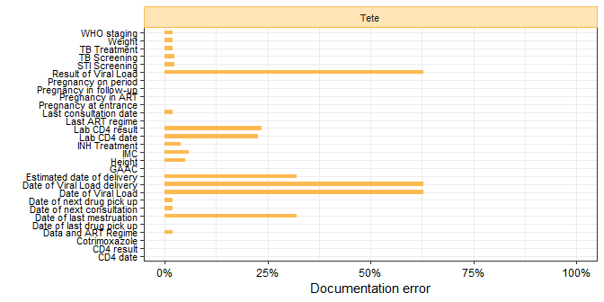

Figure 3.6: Percentage related to documentation error in Tete

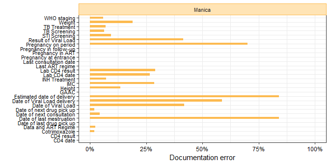

Figure 3.7: Percentage related to documentation error in Manica

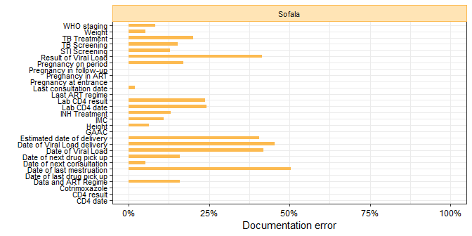

Figure 3.8: Percentage related to documentation error in Sofala

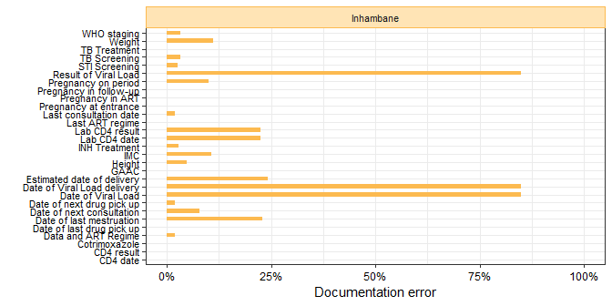

Figure 3.9: Percentage related to documentation error in Inhambane

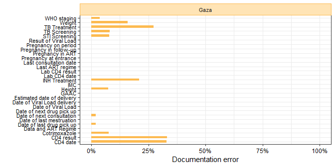

Figure 3.10: Percentage related to documentation error in Gaza

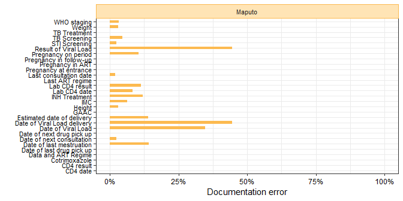

Figure 3.11: Percentage related to documentation error in Maputo province

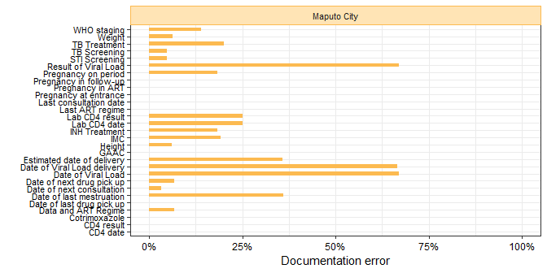

Figure 3.12: Percentage related to documentation error in Maputo City

### 3.4.2 Quality issues related to **lack of data entry** by variable in each province

Overall, most of health facilities across provinces had issues related with lack of data entry with percentage less than 20%, with some stand out issues of greater than 25% related with GAAC in Sofala and TB treatment and GAAC in Inhambane. It’s worth to refer that Nampula, Tete, Manica, Sofala, Inhambane and Gaza highlighted on issues related with lack of data entry in most of the variables assessed.

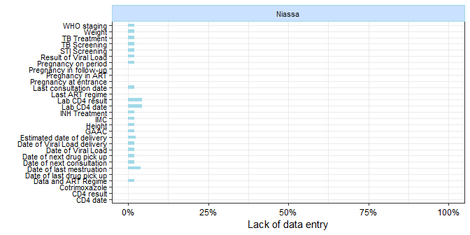

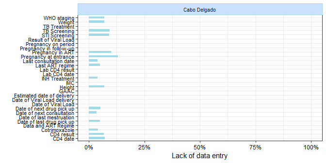

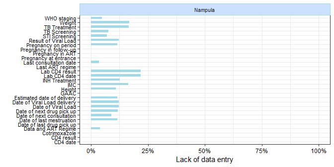

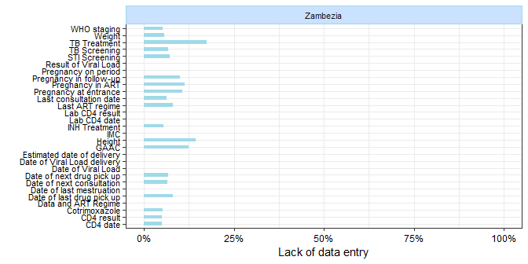

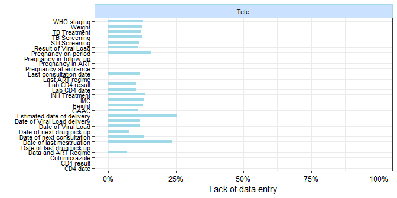

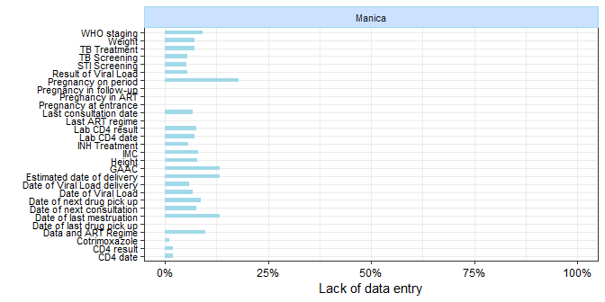

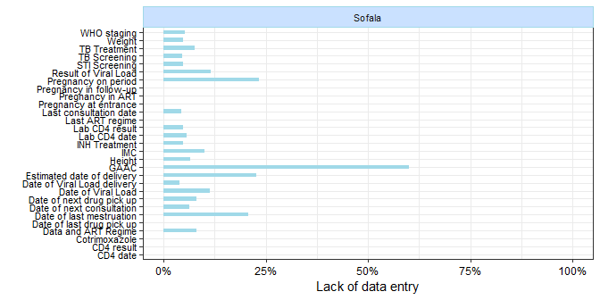

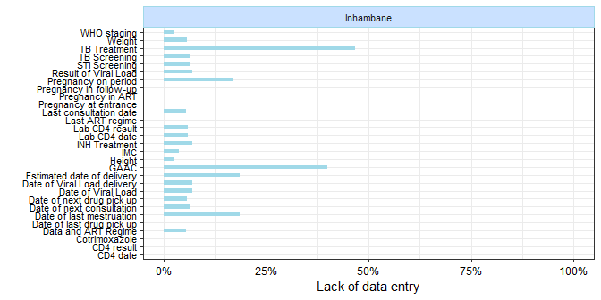

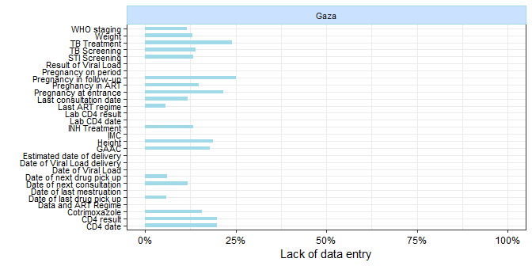

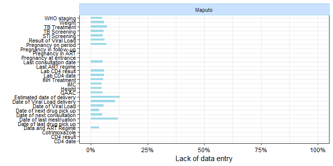

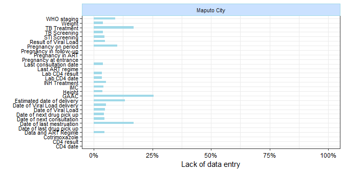